None

# How to use this notebook

This is not intended to be a replacement for a full set of ES103 notes. Those can be found [here](https://alexanderallenbrown.github.io/ES103_SP22_Students/). This is intended to be a very brief refresher that re-introduces the disciplined processes that are important to carry forth with you as you begin your third year systems course. If any of these concepts or words seem unfamiliar, consulting the full set of ES103 course notes is recommended. You can search terms and phrases using ctrl+F in the full [Resource Notebook](https://alexanderallenbrown.github.io/ES103_SP22_Students/ES103_Summary_Resource/ES103_Summary_Resource.html) from ES103.

# Introduction

## What is a Model?

A model, or more precisely, an *engineering model*, is a representation of something we want to understand. The word *representation* here means that while a model *represents* something real, and can even predict the behavior of that real thing quite accurately, it is **not the same as the real thing.** A model airplaine is a good example of a *physical model* of what we would call a "true" airplane that carries people and cargo over long distances. While it shares some features of the real airplane, it is different in some fundamental ways, such as its power source, size, and flight time. It cannot do everything that a real airplane can do... but it does enough things similarly enough that we might better understand how real airplanes work and/or how they should be built by building a model.

An *engineering model* can be physical, like a model airplane, or it may not be. What makes a model an *engineering model* is its utility for designing and/or understanding the thing it is supposed to represent.

The engineering models we will be building in this class will rarely (if ever) be physical models. They will mostly be comprised of **mathematical equations** that help us predict the behavior of physical things or processes that we wish to build or understand. The mathematical equations representing the thing or process we wish to understand will, if we do our jobs correctly, allow us to predict what will happen when something changes.

This ability to "predict" using a model is fundamental to engineering. If engineers needed to simply change design elements randomly, building full-sized airplanes over and over until one worked "just right," engineering as a discipline would be incredibly dangerous, expensive, and inefficient. Using mathematical equations to tell us what will happen when we build a design or implement a policy can allow us to avoid many costly and dangerous mistakes that would result from a "trial and error" approach.

## What is a System?

A **system** refers to any collection of items, pieces, or subprocesses that we call **elements**. These elements interact to produce a behavior we are interested in understanding and/or predicting. A system is generally described as an "isolated slice" of the universe. Anything inside that "slice" is part of the system. Anything outside of that "slice" is called the system's "environment," or its surroundings.

This means that while a system may exchange energy, material, and/or information with things that are outside of its boundaries, changes in the system's behavior are generally driven by its environment, rather than the other way around.

**Elements** are the "atomic units" of a system. They can be either *processes*, *physical objects,* or *collections* of physical objects. Their relevant behavior can be represented completely by an equation or set of equations describing how they interact with either other elements in the system or with the system's surroundings.

Elements could, in theory, be modeled as "systems" themselves, with their own sets of interacting elements. However, when we declare that something is to be considered an "element" in a system, it means that we are not interested in unpacking its behavior or construction any further.

For example, a bus could be considered an "element" in a *transportation system.* The bus itself could be modeled as a system comprised of elements like wheels, springs, an engine, and so on. However, when we say that the bus is an **element** in our transportation system, it means that we are considering the bus to be an irredicible building block in our definition of the transportation system. Perhaps this bus's behavior of interest could be modeled using only an equation relating the time of day and a "traffic congestion factor" to its position along a route.

It's true that this is a bold simplification of a bus's behavior. By making the declaration that this bus's position is the only thing we care about, and that this position can be known using only two independent variables, we are **assuming a lot.** We are **ignoring a lot.** What if the bus breaks down? Why don't we care about how it bounces over potholes, or how much fuel it uses?

Well, we **can't** model **everything**. When we decide to consider building a model of the "transportation system," we must immediately begin *simplifying reality.* We have to decide where the system (as we define it) begins and ends, and what level of complexity is required to know what we need to know about the system.

This leads us to a pair of fundamental truths about engineering models:

1. All models are *wrong* because they do not include every nuance of every phenomenon that may impact a system's behavior
2. Good models a *useful* because they sufficiently *predict* the system's behavior. They are still "wrong" in the sense that there are phenomena they will either ignore or predict inaccurately, but they are "accurate enough."

Building good models is the goal, and in ES103, we will use a simple three-step process to build a model.

## What is a *DYNAMIC* System?

A "Dynamic System" is any system whose behavior *varies significantly with time* when one of its inputs or operating conditions changes. A bridge may be a system of composed of beams that interact with one another, but if we look on a short enough time scale (years rather than decades, perhaps), the bridge's behavior may or may not vary interestingly in time, even if its elements all play interacting roles to support the weight of passing traffic. At Lafayette, ES230 (Statics) considers "trusses" (like bridges) that fall into this category.

However, it is only our **model** of a bridge that may not display time-varying behavior. *Real* bridges *do* have behavior that varies in time; it's just that as engineers, our model scope may not always include time-varying behavior. For an example of an incorrectly scoped model of a bridge, you could read about what happened to the Tacoma Narrows Bridge), which collapsed due to vibration (time-varying behavior) that it was not designed to withstand, since the engineers' model scope did not consider that type of behavior.

In ES103, we will be almost exclusively considering models of *dynamic* systems, meaning that we are interested in how the system's behavior evolves over time. Dynamic Systems display many types of behavior when subjected to a sudden change in input conditions, but many will show behavior in their *outputs* (quantities of interest) that can be roughly grouped into one of the following categories:

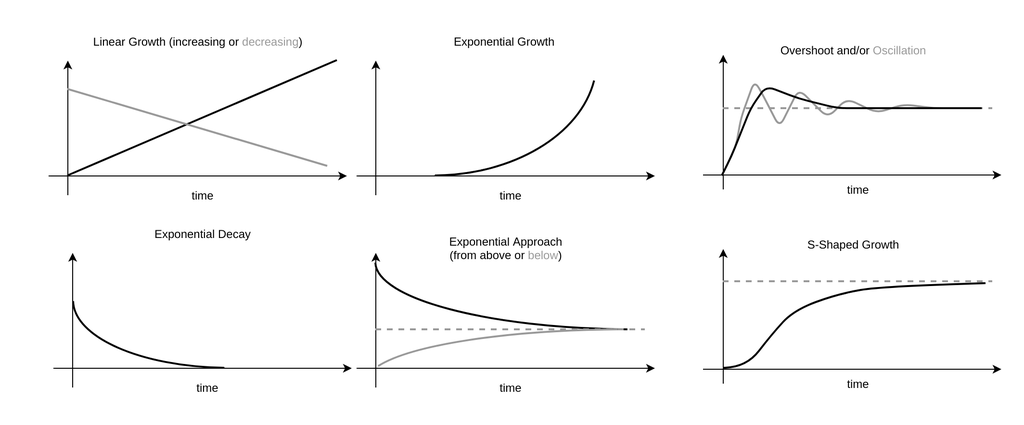

The categories of system behavior above are basic-- some complex systems exhibit combinations of these "prototypical" responses. Still, categorizing system behavior this way, and grouping systems into "families" that exhibit responses such as linear growth, exponential growth, exponential decay and/or approach, overshoot and oscillation, is often useful because it helps us develop *expectations for* and *interpretations of* a system's behavior when we observe it.

# Disciplined Processes

Below, you will find a list of disciplined processes (procedures) used in ES103 to build models.

## Disciplined Process for Model Building

In ES103, we will follow the following general procedure for building models of systems. Each of the steps in the diagram below is explained in more detail in the following sections.

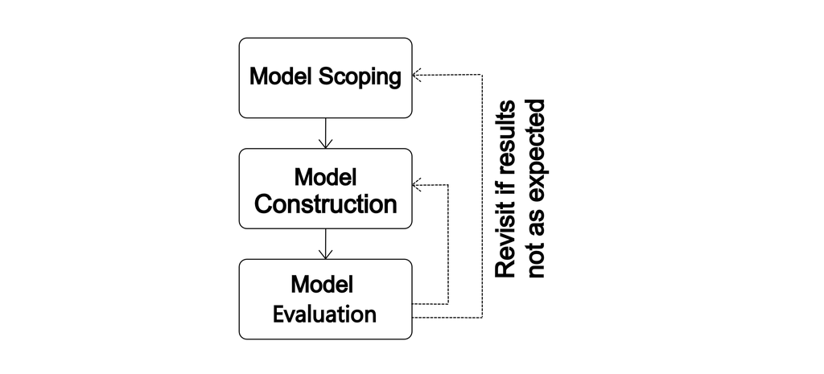

## General Disciplined Process for Scoping Dynamic System Models

When we attempt to model a phenomenon or series of interconnected phenomena as a "system," we are looking for a collection of elements that interact with each other and the system's surroundings to produce the behavior we are interested in understanding. Defining the boundary that indicates what is "inside" the system and what is not is what we will call **model scoping.** The process of "scoping" a system model involves drawing the system boundary, and answering the following three questions:

1. What quantities (energy, material, information) go *in* to the system boundary that are relevant to the behavior we're interested in?
2. What quantities (energy, material, information) go *out* of the system boundary that are relevant to the behavior we're interested in?
3. What quantities (energy, material, information) are *stored within the system boundary?*

More specifically, you should be sure to complete the following steps:

- Draw your system's physical boundary in an overall energetic diagram. Show power flow into and out of the system. Indicate inside of the energetic diagram how you are splitting your system up into elements. Generally, "idealized sources" should go *outside* of your system scope. Clearly indicate which independent variable(s) is/are your system's *input(s)*.
- Including an equivalent circuit in your scoping process is a good idea! Label this equivalent circuit so that writing your elemental, node, and loop equations later is easy.
- Separate your system's elements into a list of energy storage and energy dissipation elements to help determine system order, or separate them graphically in your system-level energetic diagram.
- Count and indicate the number of *independent* energy storing elements in your system. If you are not sure what elements are independent, use their energy storage equations to check!
- Indicate whether you intend to build an input-output or a state-space model for the system. Write down a general form you'd expect your final model to take so that your algebra stays focused when the time comes.
- Form a list of your independent and dependent variables. If you are building a state space model, it is especially important to carefully choose your system's states based on how the energy storage elements store their energy.

## Disciplined Process for using Energy Conservation and Equivalent Circuits to Construct a Model

In this section, we unpack "step 3" in the general discplined process for Model Construction. The use of equivalent circuits means that we can take explicit advantage of two particular forms of the energy conservation equation: node equations (KCL) and loop equations (KVL). KCL lets us represent power transfer between elements when the T-type power variable splits and the A-type variable is constant. KVL lets us represent power transfer elements when the T-type variable is constant but the A-type variable is not.

1. Draw an energetic diagram for each element in your model scope, crossing off any terms you are assuming to be insignificant. When you do this, *justify* each assumption clearly in writing. Making an assumption is always a deliberate risk; the model evaluation step of our overall disciplined process for ES103 will guide you in determining the quality of the assumptions you make.
   1. You may reference the assumptions in the "standard" lumped element table in your justification, but you must still give a reason for assuming that an element acts like one of these "standard" element.
   2. Represent (if possible) each of your elements as a generalized circuit element.
2. Write the time-derivative of the first law of thermodynamics for each element to describe how the element transfers energy between itself and its surroundings. Take care to substitute what you know about the energy, work, and heat terms for each element into the equation.
   1. You may cross out any "extra" power variables in each final first-law equation for each element (e.g. $V_{12} i = i^2R \rightarrow V_{12} = iR$)
3. Represent connections between your system's elements by drawing the system as an equivalent circuit. Use physical connections between elements in your system to guide you here. Write equations that indicate how each element in your scope exchanges energy between itself and other elements in the scope, or between itself and the overall system's surroundings. Specifically, power linkges between elements can be written using Krichoff's Current Law (continuity) and Kirchoff's Voltage Law (compatibility):
   1. Construct and label your "equivalent circuit." This may be an iterative process as you identify nodes and loops in your system (see below).
   2. Identify "nodes" in your system and write the principle of continuity for these nodes (e.g. $i_1 - i_2 - i_3 = 0$).
   3. Identify "loops" in your system and write the principle of compatibility for each loop (e.g. $V_{41}+V_{12}+V_{23}+V_{34}=0$.
4. Using algebraic manipulation, combine your equations from steps 2 and 3 to obtain a final system model that includes only independent variables, dependent variables, and their derivatives.
5. Check your final system model for internal validity, including the signs and units of each term, and the overall form of the equation.

## Disciplined Process for Model Evaluation

Our overall disciplined process for model evaluation consists of two steps:

1. Check *internal validity* of the model (whether the model is consistent with physical laws)
2. Check *external validity* of the model (whether the model describes reality for an appropriate range of model and parameters and experimental conditions)

# Model Construction Tools

In this section, we will briefly review key terminology and skills needed to execute the disciplined processes in the preceding section.

# The First Law of Thermodynamics: The conservation of Energy

In ES103, we use the conservation of energy as our primary tool for model construction, so understanding the use of equivalent circuits and "equivalent lumped elements" to build models of dynamic systems starts with an understanding of energy conservation.

The first law of thermodynamics, also called "the conservation of energy," states that energy is never created nor destroyed... merely exchanged between a system and its surroundings. It is this law that tells us that [perpetual motion machines cannot exist](https://en.wikipedia.org/wiki/Perpetual_motion), as they produce work without the input of energy from outside of the system.

Because energy can only be transferred through either work, mass transfer, or heat transfer across a system boundary, we can draw the relationship between a system of interest and its surroundings using the following diagram:

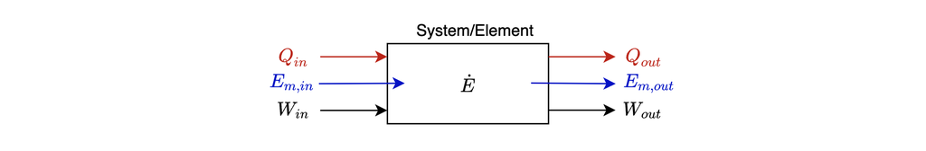

You may notice that this looks like our "system scope" diagram, but it deals with energy only. We represent internal (stored) energy $E$, work done on the system from the external environment $W_{in}$, work done *by* the system on its external environment $W_{out}$, heat applied *to* the system from the external environment $Q_{in}$, heat applied *by* the system to its external environment $Q_{out}$ explicitly. We also explicitly call out terms $E_{m}$, which represent energy transfer due to mass crossing the system boundary (either into our out of the system).

Formally, we can write the change in energy *stored* inside the system from some "initial state" 1 to some "later state" 2 using the following equation, which is a statement of the first law:

$$ E_2 - E_1 = \Delta E = \delta W_{in} - \delta W_{out} + \delta Q_{in} - \delta Q_{out} + \delta E_{m,in} - \delta E_{m,out}$$

This says that if the balance of energy transfer between our system and its environment can be interpreted as the environment "doing work" on, contributing energy via mass transfer to, or "transferring heat to" our system of interest, it will increase the amount of energy stored *inside* our system if our system did not do work on its environment, contribute energy via mass transfer to, or exchange heat with its environment.

In the opposite scenario, if balance of energy transfer between our system and its environment can be interpreted as our system "doing work" on its surroundings or "transmitting heat to" its surroundings, we say that the amount of energy stored in our system goes down.

If we consider that bringing our system from "energy state 1" to "energy state 2" requires time (which it always will), we can say that the *rate of change in energy in our system* can be written as:

$$ \frac{E_2 - E_1}{t_2-t_1} = \frac{\Delta E }{\delta t}= \frac{\delta W_{in}}{\delta t} - \frac{\delta W_{out}}{\delta t} + \frac{\delta Q_{in}}{\delta t} - \frac{\delta Q_{out}}{\delta t}+ \frac{\delta E_{m,in}}{\delta t} - \frac{\delta E_{m,out}}{\delta t}$$

Shrinking $\delta t$ to an infinitesimal value leads to the derivative of our original first law equation, which is a totally equivalent statement about the conservation of energy:

$$ \dot{E} = \dot{W}_{in} - \dot{W}_{out} + \dot{Q}_{in} - \dot{Q}_{out} + \dot{E}_{m,in} - \dot{E}_{m,out}$$

The derivative of energy (and thus, the derivatives of power and heat) have units of $\frac{J}{s} = \frac{kgm^2}{s^3}$, which are commonly called "Watts" in SI units. There is also a very special name for the time-derivative of energy, and it is **power**.

## Power Variable Types

In all three of the types of physical systems (mechanical, electrical, hydraulic) we've studied, it is possible to write an equation for how power flows between system elements. For example:

1. In a mechanical system, power is $F\cdot v$ for translational systems and $T\cdot \Omega$ for rotational systems
2. In an electrical system, power is $V \cdot i$
3. In a fluid system, power is $P \cdot \dot{\mathcal{V}}$.

If the first law of thermodynamics tells us that one of these two variables is conserved at a "node," we interpret this as a statement that it represents a quantity flowing "through" the node. We call this type of variable a "through type variable." In mechanical, electrical, and fluid systems, these are force, current, and flow rate, respectively.

If a variable must be measured with respect to some fixed reference in order to have meaning, and is different from one node in our model to the next, it is called an "across type variable."

For example, velocity must be measured with respect to an inertial reference frame, and varies from one end of an idealized damper to the other. Voltage must be measured with respect to some reference "ground" voltage, and varies from one end of a resistor to another. Pressure must be measured by a gauge which references some environmental (atmospheric) reference pressure, and varies from one end of a valve to the other.

## The principle of Continuity

The principle of continuity is a re-statement of the first law of thermodynamics with specific assumptions. For many types of systems, the assumptions boil the first law of thermodynamics down to a simple statement about conservation of mass. In these cases, the principle of continuity states:

"flows into a node must balance with flows out of a node,"

Where the definition of "flows" depends on the type of system at hand. For electrical systems, the principle of continuity at a node boils down to a "conservation of current," or Kirchoff's Current Law:

$$\sum i _{node} = 0$$

With currents into a node considered positive, and currents out of a node considered negative.

For a mechanical system, Force is the quantity that "flows through" elements via Newton's 3rd law (making an imaginary cut anywhere along a rigid body and drawing a free body diagram will confirm this). Thus, a "node" in a mechanical system is an imaginary element with "no" mass. Writing the first law of thermodynamics for a node in a mechanical system, and canceling that its (single) velocty from the first law equation, one obtains:

$$\sum {F}_{node} = 0$$

For a fluid system (incompressible), a "node" might represent an infinitesimal junction between two pipes or valves, or a junction between a valve and a tank. Writing the first law of thermodynamics for this "infinitely thin" element in which only one pressure exists (and can thus be canceled), one obtains:

$$\sum \dot{\mathcal{V}}_{node} = 0$$

With volumetric flows into the node being considered positive, and flows out of the node negative.

## The Principle of Compatibility (Kirchoff's Voltage Law)

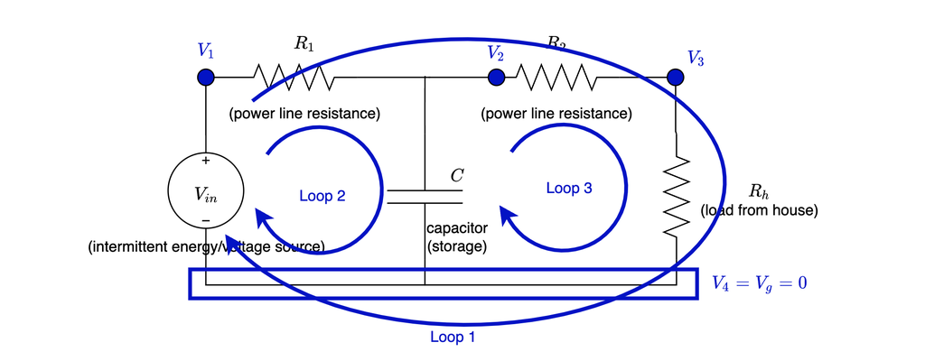

For Loop 1, the principle of compatibility states: $$\require{cancel}$$ $$ V_{41} + V_{12} + V_{23} + V_{34} = 0$$

Which, given the definition of $V_a - V_b = V_{ab}$, could be re-written as:

$$ \cancel{V}_{4} - V_1 + V_1 - V_2 + V_2 - V_3 + V_3 - \cancel{V}_{4} = 0$$

Similarly, for Loop 2, the principle of compatibility states:

$$V_{41} + V_{12} + V_{24} = 0$$

And for Loop 3, the principle of compatibility states:

$$V_{42} + V_{23} + V_{34} = 0$$

Compatibility can also be appled to fluid systems (replacing voltages with pressures) and to mechanical systems (replacing voltages with velocities or angular velocities).

## Generalized Idealized Elements

All of the "idealized" system element types we have talked about thus far, by the assumptions applied to their first law equations, either store energy or transfer it to the surrounding environment. This means that all of the elements we've discussed (other than "nodes") have different amounts of power flowing into and out of them. These elements are often visualized as having two "ports," one into which power flows, and one out of which power flows. A drawing is shown below:

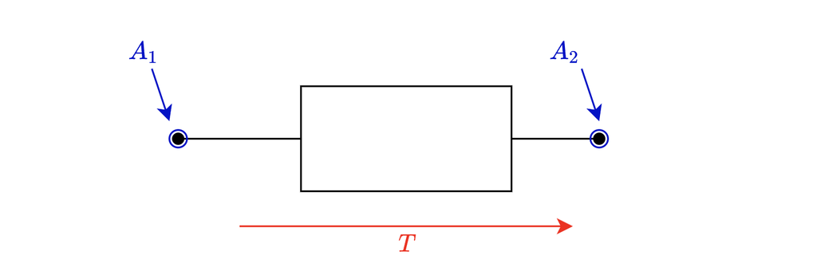

The generalized element above will have two distinct values of the A-type variable at each "end" (some systems textbooks call these 'ports'), either because the element is accumulating energy (like a mass, capacitor, or tank does), or because it is transferring energy to outside the system boundaries (like a resistor, damper, or valve). We will typically **label the inside** this element with the independent variable that dictates its ability to store energy (e.g. $C$, $m$, $J$) or dissipate energy (e.g. $b$,$R$).

Visualizing elements in this general way allows us to connect elements of our systems together into generalized "equivalent circuits." Doing this provides *operational efficiency* in using energy conservation (the first law) to build models for our systems.

Assuming no significant net energy transfer via mass flow (as we have in all of our 'standard' elements so far), the first law of thermodynamics for this element could be written:

$$\dot{E} = \dot{W}_{in} - \dot{W}_{out} + \dot{Q}_{in} - \dot{Q}_{out}$$

Then, recognizing that $\dot{W} = A\cdot T$, we could write the *power portion* of the first law equation as:

$$\dot{E} = A_1T - A_2T + \dot{Q}_{in} - \dot{Q}_{out}$$

note that the visualization of our generalized element **does not show** whether the element stores energy or transfers it to the element's surroundings as heat. As such this is **not** a complete energetic diagram. **We need to know what the $\dot{Q}$ terms and the $\dot{E}$ term should be for our element.** These terms are often based on similar sorts of assumptions, and yield two common types of "generalized elements."

### Energy Storage Elements

If an element *stores* energy, but does not transfer a significant amount to its surroundings via heat, it is generally called an "energy storage element." If it stores energy via its across-type variable, it is called an "A-type storage element." Masses, rotational inertias, capacitors, and fluid capacitors are all A-type storage elements. If the element stores energy via its through-type variable, it is called a "T-type storage element." For energy storage elements, zero heat transfer to the element's surroundings is often assumed, which reduces the first law equation to:

$$\dot{E} = A_1 T - A_2 T$$

### Dissipative Elements

If an element does not *store* significant energy, but does transfer significant energy to the element's surroundings via heat, we call that element a "dissipative element." Dissipative elements include electrical resistors, valves, and idealized dampers. The assumption of no energy storage for dissipative elements yields the generalized first law balance of:

$$\dot{Q}_{out} = A_1 T - A_2 T$$

### Do all physical things fall into one of these two categories?

No. It may not be reasonable to represent every physical "part" of every system as one of these two things. However, Elements that display significant energy storage *and* energy dissipative behavior can, under many circumstances, be represented by a combination of a dissipative and a storage element. We call this a "lumped element" approximation, where a "real" element is broken down into a combination of idealized storage and dissipative elements.

## Generalized Equivalent Circuits

By conceptualizing each of our idealized elements as having two ports through which power flows, much like an electrical component has, we can arrange the elements into an equivalent circuit that shows us how power flows from one element to another. An example is shown below.

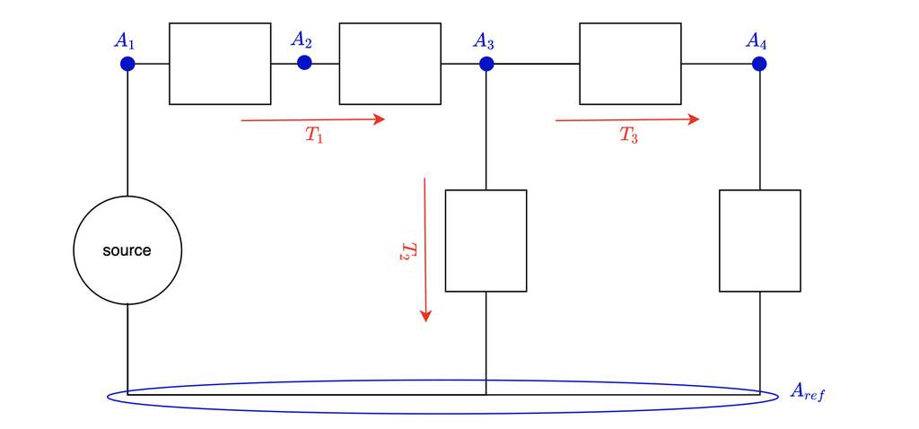

This circuit has a source (which we often model as having a defined, known value for either the T-type or A-type power variable, and thus "infinite" power potential), and 5 idealized elements. Distinct values of the across-type power variable are shown in blue, and distinct values of the through-type variable are shown in red. This circuit-like network allows us to write compatibility relations (loops relating the A type variables) and continuity relations (nodal equations for the T type variables) to aid in model construction.

Note that while this configuration allows for easy use of the first law of thermodynamics for studying how power flows from one element in our system to the others (compatibility and continuity relationships), it **does not** tell us explicitly about energy storage or dissipation for each element. Individual first law balances for each element are required, along with the construction of loop and node equations, to use the equivalent circuit for model construction.

Note that typically, the blank box used to denote each element would include the element's primary parameter. For example, a damper might be drawn as a box with a "b" in it to represent its damping coefficient. A mass might be drawn as a box with an "m" in it. A capacitor might be labeled "C."

## Idealized Power-Converting Transducers

An idealized, power-converting transducer, like all of the other physical system elements we have studied, obeys the conservation of energy. However, like the other idealized element types we've talked about, the power-converting transducer only does "one job," and that is power conversion. Therefore, if something can be said to be adequately modeled as a power-converting transducer, it cannot store energy or transfer it to the system's surroundings. In other words, its first law of thermodynamics equation in power form looks like this: $$\require{cancel}$$ $$\cancel{\dot{E}} = \dot{W}_{in} - \dot{W}_{out} + \cancel{\dot{Q}_{in}} - \cancel{\dot{Q}_{out}}+\cancel{\dot{e}_{m,in}} - \cancel{\dot{E}_{m,out}}$$

Simplified, we find the fundamental equation that defines an idealized power-converting transducer:

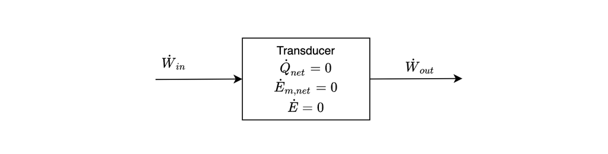

$$\dot{W}_{in} = \dot{W}_{out}$$

While this looks a bit like the equation we used to define a "node," for a transducer, $\dot{W}_{in}$ and $\dot{W}_{out}$ will always represent a change in the power variables from the "input" side to the "output" side of the element.

## Representing Power-Converting Transducers in Equivalent Circuits

There is no grand universal symbol used for representing power-converting transducers in equivalent circuit diagrams. We will simply pick a symbol with the knowledge that others are possible, but all must have four "ports" in order to connect two equivalent circuits that show two different *types* of power flow.

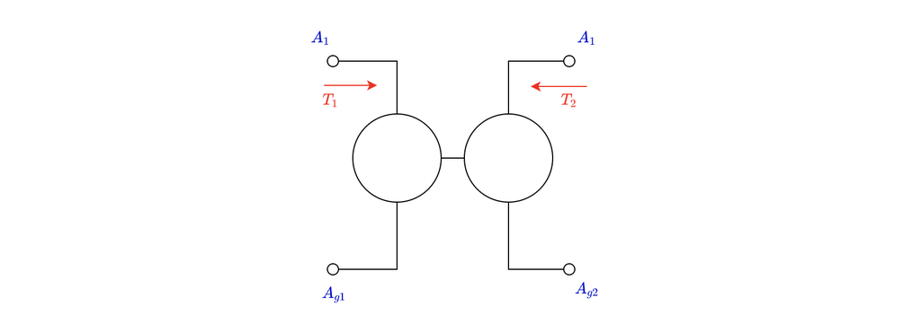

## Independent Energy Storage Elements and System Order

In a lumped-element model of an engineering system (such as those we have been building, where each element in the system scope either stores or dissipates energy), the number of *significant, independent* energy storage elements is equal to the number of derivatives required to model the system. The number of derivatives needed to represent a system's behavior is often called the system's "order."

For example, a **single differential equation** representing a model of a system that has 3 significant, *independent* energy storing elements would need to have a triple derivative of the dependent variable, a double derivative of the dependent variable, and a single derivative of the dependent variable in the equation in order to fully describe the system behavior. This is because each derivative is a representation of how the energy in the total system (consisting of 3 energy storage elements) can change. A single differential equation representing a system's dynamic behavior is often called an *input-output* model, because the single differential equation represents a relationship between the system's input (source of power from outside of the system scope) and its output (our dependent variable).

Representing your model as a single differential equation is not the only option. If your model is represented not as a single input-output differential equation but as a list of coupled first-order differential equations in State Space Form, the number of coupled, first-order differential equations you need to represent the model is equal to the number of independent energy storing elements in your scope.

## Dependence and Independence of Energy Storage Elements

Two energy storing elements in a system model are *independent* of one another if the energy stored in one element *cannot* be directly written simply as a scaled version of the energy in another.

Two or more elements are *dependent* when Their energy storage equations can be directly related by a constant scale factor.

This often occurs if the two elements are *directly in series* (where the T-type variable is common between them but the A-type drop across each is different) or *directly in parallel* (where the A-type drop between them is common but the T-type variable in each is different) in an equivalent circuit representation, and in *some cases* when two energy storing elements are connected by a transducer with no dissipative elements in between them.

## Input-Output Differential Equation Models

An input-output differential equation model is a single differential equation represents a relationship between the system's input (source of power from outside of the system scope) and its output (our dependent variable). Generally speaking, this type of model can be written as:

$$ \frac{d^n y}{dt^n} = f\left(y,\frac{dy}{dt},\frac{d^2 y}{dt^2},\cdots,\frac{d^{n-1} y}{dt^{n-1}},u,\frac{du}{dt},\frac{d^2 u}{dt^2},\cdots,\frac{d^{m-1} u}{dt^{m-1}}, \frac{d^{m} u}{dt^{m}}\right)$$

Don't let the notation scare you. This just means that the highest derivative of our output $y$ **is a function of** or **depends on** the output and its derivatives (up to a highest order $n-1$, along with the input and any of its derivatives that are relevant (up to a highest order $m$). **You have already been doing this all semester!** Your models have mostly been in the form:

$$ \frac{dy}{dt} = \square y + \square u$$

**Which is an input-output model as defined above!!** As you can see, the equation above is an input-output differential equation with $n=1$ and $m=0$, where the first derivative of our dependent variable $y$ is a function of $y$ itself, and our input $u$ . The "order" of a differential equation is equal to $n$, the number of derivatives of the output (dependent variable) $y$ present in the equation.

### Building Input-Output differential equation models

Deriving input-output models for "higher-order" systems is done using our disciplined process from Reading 15. There are essentially no modifications to this process for finding input-output models for systems with an order higher than 1. As you work through the algebraic reduction of your model from the "menu" of elemental, node, and loop equations, expect to take the derivative of one or more intermediate equations as you strive to eliminate unknowns.

## Differential Equation Models in "State Space" Form

Sometimes, building a model of a differential equation model that has an order of 2 or higher in input-output form is algebraically difficult and cumbersome. Luckily, there is a simpler way to represent a differential equation model that may represent a system with multiple independent energy storing elements. It is called a "state space" model.

The term "state space" comes from the fact that the model fully describes the system's energetic "state," or the total energy inside the system. If we pick *multiple* dependent variables rather than one, and that set of dependent variables can fully describe the system's total energy, then we can write a *list* of *coupled* differential equations that represent our system. While the study of state space systems is often reserved for late undergraduate or even graduate study, the concept is fairly simple.

Assume we have a list of $n$ dependent variables for our system because our system has $n$ independent energy storing elements. Let's make their names general to avoid putting ourselves in a box and call these $x_1$, $x_2$, $x_3\ldots,x_n$. Most of the time, these will be either T-type or A-type power variables in a physical system. Let's also assume that, together, these variables fully describes the system's energy storage. Lastly, we will assume that our system has a single external source of power that is described by a known input $u$.

We can then manipulate our system's element, loop, and node equations to get the following list of *first order* differential equations that describe our system's behavior:

$$ \left\{ \begin{matrix} \frac{dx_1}{dt} &=& f(x_1,x_2,\ldots,x_n,u) \\ \frac{dx_2}{dt} &=& f(x_1,x_2,\ldots,x_n,u) \\ \vdots &=& \vdots \\ \frac{dx_n}{dt} &=& f(x_1,x_2,\ldots,x_n,u) \end{matrix} \right. $$

To read this, a few clarifications will be helpful. What this list says is that the first derivative of each of our **states** $x_1,x_2,\ldots,x_n$ **MAY DEPEND** on any or all of the *other* system states, and/or the input $u$. It does not state that each equation **MUST** depend on all of these. Any dependence between one state derivative equation and the *other* system states is called "coupling." This list is a list of *coupled* first-order differential equations. Later in your career, you may see this written compactly in vector form:

$$\frac{d\vec{x}}{dt} = f(\vec{x},u)$$

Which saves a bit of writing if we just consider the "state vector" $\vec{x}$ to contain all of our system's states. A state space model is, in its most general form, a "vector differential equation," which unlocks a whole set of analysis tools that are unfortunately beyond the scope of this course. For now, we will continue to need to simulate our model numerically to investigate its behavior.

This concept may seem a little more complicated than input-output form at first glance, but building a state space model is really in many ways easier than building an input-output model. Note that technically, **all of the first-order models you built this year are already in state space form**, just with $n=1$.

### Choosing state variables for a state space model

You may be wondering how to know what to choose as your set of dependent variables in a state space model. When you take differential equations, and possibly a higher-level systems course, you will likely learn that *there is no one answer to this question*. State space models are not unique, and *any* set of variables that can, in its whole, describe the system's current total stored energy is acceptable.

However, for this course, we will simplify our lives and stick with one approach, which is to choose a state variable that describes the energy storage in each *independent* energy storing element in your system. For an electrical system, you might choose to use the voltage across each independent capacitor, since they store energy as $E_c = \frac{1}{2}CV_{12}^2$. For a fluid system, you might do the same but with pressures across each fluid capacitor. For a mechanical system, you might choose the velocity or angular velocity of a mass or rotational inertia respectively, since $E_m = \frac{1}{2}mv^2$ and $E_J = \frac{1}{2}J\Omega^2$.

### Reducing a "menu" of element, node, and loop equations to a suitable state space model

To build a state space model, first analyze the system's components individually, and analyze how power flows within the system boundaries using loop and node equations.

Then, you would do well to begin by solving each independent energy storage element's equation for the derivative of its power variable. This is a great first step because the power variable for each energy storage element is probably one of your "state variables!"

If you follow the two steps above, you already have your "state space form" started. Then, using substitution, eliminate all unknowns by substitution.

**TIP**: If you have a few "dependent" energy storage elements in your system, try to eliminate the "extra" power variables associated with these early on. An example would be a system with a rack-and-pinion gear: your "state" for that part of the system might be velocity, so you'd want to eliminate angular velocity early on to help with algebra.

## ES103 List of Standard Elements and Assumptions

With our last three energy storage elements taken care of, we can produce a complete list of all of ES103's standard assumptions and elements for physical systems.

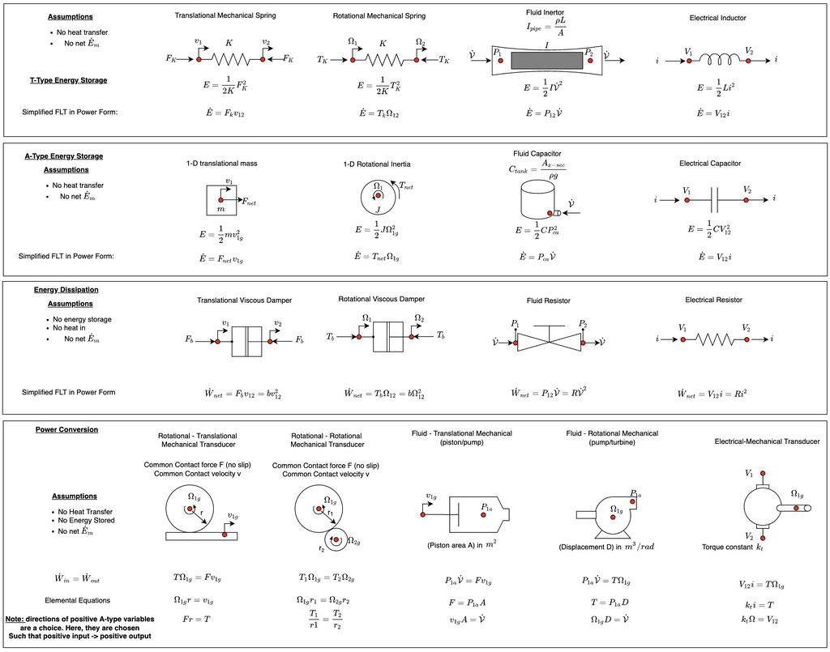

# Model Evaluation Tools

## Internal Validity of Input-Output Differential Equation Models

We assess a model's internal validity using the following tools:

1. Check that the form of the model is appropriate given our system scope.
2. Check the signs of all terms in the differential equation to ensure that the system reaches a steady state (dependent variable reaches a constant value as $t\rightarrow \infty$).
3. Compute the model's steady state value by setting derivatives of the dependent variable equal to 0 to confirm that it meets expectations.
4. Check the units of each term in the model.

For question 1, we ask "Is my model a differential equation, and should it be?" Recall that it "should be" if the system stores energy. The same reasoning applies for higher-order input-output differential equation models. You can further confirm that the number of derivatives in your model is equal to the number of *independent* energy storing elements in your scope.

For question 2, things get a little more complicated for systems where $n>1$. For systems with $n=2$, we can still check whether the model reaches a steady state by ensuring that all terms multiplied by our dependent variable $y$ on the right-hand side are $<0$, which tells us that the system's energy will *decrease* more rapidly as the dependent variable (and its first derivative) increase. **HOWEVER**, the situation is much more complicated for systems where $n>2$, and we do not have (and will not learn) the tools for checking the *stability* of systems with order greater than 2 in this course. You will learn these tools in your differential equations course.

## Internal Validity for State Space Differential Equation Models

We will use the same steps here as we used above for input-output models. However, determining whether our system will reach a steady state is possibly even more difficult for a state space model of higher order. This is because of the coupling between the equations. Steps 2 and 3 are thus much more difficult, and you are not expected to be able to perform this step for higher-order models in ES103.

## External Validity for differential equation models

Because ES103 does not assume that you have taken a differential equations course, our only way to assess the *external validity* of a model, or its ability to generalize and describe our system when parameters are changed, is by solving a differential equation model numerically. Our strategy for this is to use Euler's method of numerical integration.

### Approximate Integration: Euler's Method

In Euler's method of approximate integration, also called the "rectangular approximation" of an integral, The area under a curve, $y(t)$, which yields $\int y(t) dt = Y(t)$, can be *approximated* by repeatedly summing the area of rectangles projected either forwards or backwards in time from each discrete measurement of $y$. The process begins with some initial, known value of the integral $Y_0$, the value of $Y(t)$ is incremented by the area of the corresponding rectangle on the plot of $y(t)$. The process is shown visually below.

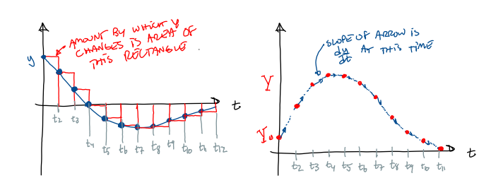

As you can see in the second plot, the idea is to use one, known value of our integral, $Y$, at the very start of the procedure. This is often called the *initial value* of $Y$. Then, the area under the derivative plot from $y(t_1)$ to $y(t_2)$ is added to our estimate of $Y$, and this value, when added to $Y_0$, becomes $Y(t_2)$. Formally, this can be written as:

$Y(t_2) = Y_0 + y(t1)\cdot(t_2-t_1)$

From $t_2$ to $t_3$, the procedure is repeated. In other words, the rectangle defined by the value of $y(t_2)$ is used to add "a little more" to our estimate to produce $Y(t_3)$. Formally,

$Y(t_3) = Y_0 + y(t_1)\cdot(t_2-t_1) + y_(t_2)\cdot(t_3-t_2)$

Using a "recursive formulation," we could equivalently write:

$Y(t_3) = Y(t_2) + y(t_2)\cdot(t_3-t_2)$

And so on. **In this description, we projected the value of $y$ forwards in the creation of our approximate rectangles. Therefore, this particular variant of Euler integration is called "Forward Euler" integration.** "Backward Euler" integration is also possible. As with approximations of derivatives, the smaller the differences between times we use in the projection of the rectangles, the better our approximation of the derivative will be.

Because approximate integration is often performed on data arranged as arrays, we can use the counting index $k$ to write this as an equation that could be built into a "for loop" and computed efficiently in code. Considering arrays representing time $t$, derivative $y$, and integral $Y$, we could write an equation for any entry in the output array $Y(k)$ as:

$Y(k) = Y(k-1) + y(k-1)\cdot(t(k)-t(k-1))$

This should look similar to the equation for a line that you might use for *linear extrapolation*. Indeed, this equation is an equation for a line in point-slope form. We use each estimate for $Y(k-1)$ to produce an estimate for the *next* value of our integral $Y(k)$ using linear extrapolation. This is shown visually on the right panel of the plot above.

An example of how to implement approximate Euler integration in MATLAB/Octave is shown below. The approximate integral is compared with the "true" integral of the function to show its accuracy. Try changing the timestep $T$ in the code cell below to see how accuracy is affected by the size of the time step used for extrapolation/integration. A large value of $T$ is problematic for the same reason large extrapolations were problematic in Reading 4.

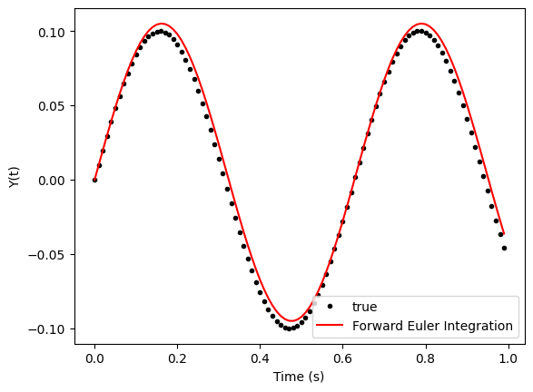

```python
from numpy import *
from matplotlib.pyplot import *

T = 0.01; #timestep
t = arange(0,1,T) #time vector
y = cos(10*t); #function we wish to integrate. This may come from data rather than a known function of t.

Y_estimate = zeros(size(t)); #initialize an array to hold our estimates for Y, the integral of y.
Y0 = 0; #some initial, known value for the integral at the beginning.
Y_estimate[0] = Y0; #place this value in the first entry of our array

Y_true = 0.1*sin(10*t); #for this example, we know that d/dt(sin(t)) = cos(t).
#We will use this "exact" solution to the integral to allow us to see how accurate Euler integration is.

#now set up a for-loop starting at the second entry in Y_estimate, since we already know Y_estimate(1)=Y0
for k in range(1,len(t)): #automatically set up the for-loop to be the right length
    #now implement Euler's formula. remember that here, y is dY/dt.
    Y_estimate[k] = Y_estimate[k-1] + y[k-1]*(t[k]-t[k-1])


#now we will compare our approximate integral with our "true" value to see if Euler integration works.

figure
plot(t,Y_true,'k.',t,Y_estimate,'r')
xlabel('Time (s)')
ylabel('Y(t)')
legend(['true','Forward Euler Integration'])
```

As you can see, Euler integration can be fairly accurate. Try different values of the time step $T$ in the code cell above to see how its value affects the accuracy of Euler integration.

In your challenge for this week, you may find this quick way to perform the 'repeated extrapolation' you used in the last assignment helpful. It is also true that in your case, your derivative ($y$ in the example above) is *related to the current value of the integral $Y$*. This is an easy difference to account for in your solution, but only if you have an equation for $y$ as a function of $Y$. In the last assignment, you may have "eyeballed" this functional relationship. This time, you may want to use a new tool: the polynomial fit.

### Euler's method for differential equations

#### Introduction

To perform Euler integration to solve a differential equation, the process is exactly the same, **except** that we do not have a vector of known values for $y$! We will instead use the differential equation to get the "slope estimates" we need for numerical integration.

Imagine that you produced a model $\frac{dy}{dt} = -4y +2$, where your dependent variable was $y$ and your independent variables were the parameters "4" and "2," along with time $t$.

#### Feedback in differential equations

As we can see, $\frac{dy}{dt}$ *depends on the value of $y$ itself*, which makes Euler's method slightly more complex. How? If we were to visualize this relationship using a special flow chart called a "block diagram," we might draw:

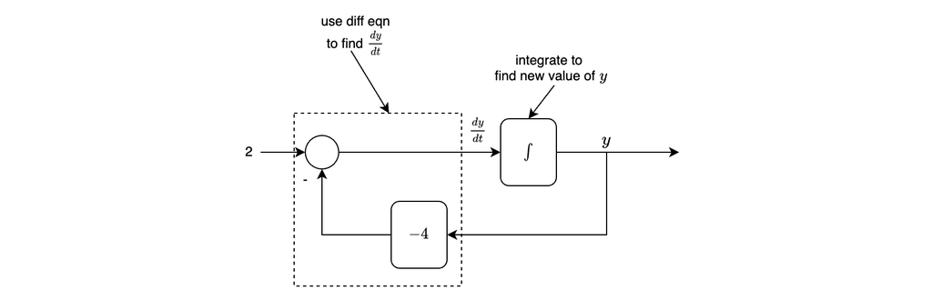

The block diagram is a visual representation of the fact that information about the value of $y$ is "fed back" into the computation of $\frac{dy}{dt}$. The round circle represents addition, and rectangles represent "operations" like multiplication and integration. This means that we can see that the equation: $$\frac{dy}{dt} = -4y + 2$$ Is represented in the diagram, with the result of the addition of $-4y$ and $2$, which is $\frac{dy}{dt}$, being sent into an integration function.

#### Euler's method for differential equations: implementation

The feedback in our differential equation means that in our "for loop" for integration, we have to *use our most recent estimate for $y$* when computing our derivative $\frac{dy}{dt}$. This has to happen at every time step! See the example below, which uses Euler's method to solve our differential equation.

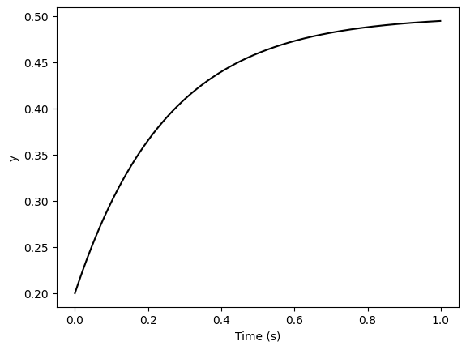

```python
from numpy import *
from matplotlib.pyplot import *
#create a time vector
t = arange(0,1,.001);
#create a vector of zeros to hold our y estimates
y = zeros(size(t));
#declare the first element in "y" as our best guess for the FIRST value of y (could be from a dataset, or knowledge of an experiment)
y[0] = 0.2;

#loop through time values to perform integration. start at the second value of time, since we already have a guess for y at the first value!
for k in range(1,len(t)):
    #first use the differential equation to compute dy/dt (slope) based on our best guess for y at the previous time
    dydt = -4*y[k-1] + 2; #2 is a constant, but it doesn't have to be. I could have a vector of known values for 2 as well.
    #now extrapolate (integrate) to our current time to get a new estimate for y!
    y[k] = dydt*(t[k]-t[k-1]) + y[k-1];

figure
plot(t,y,'k')
xlabel('Time (s)')
ylabel('y')
```

## Investigating External Validity Using Euler Integration

Once we have a differential equation model for a system's behavior that passes internal validity checks, we can see how that model matches data by simulating it using Euler integration. Suppose we have a differential equation model for a truck slowing down from some initial velocity:

$$\dot{v} = - \frac{1}{\left( J_w + m_w r^2 + \frac{m_c r^2}{2} \right)}b v$$

We can simulate this model's behavior and compare it to data as follows:

```
30
```

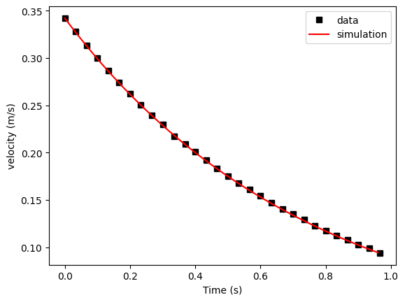

```python
from numpy import *
from matplotlib.pyplot import *

#load the data we will use for model validation
data = loadtxt('reading6data.txt');
td = data[:,0];
vd = data[:,1];
#set up a new time and velocity vector to use for simulation
dt = .01;
simtime = td[-1];
tsim = arange(0,simtime,dt);
#initialize values for simulation
print(size(vd))
vsim = zeros(size(tsim))
#set the initial variable
vsim[0] = vd[0];

#define the measured parameters for the toy truck parts
mc = .05; #kg, truck mass
mw = .01; #kg, mass of one axle, including 2 wheels
rw = .005; #m, radius of wheels
Jw = 1/2*2*mw*rw**2;
b = 1.5e-6;

#use Euler integration to simulate our model
for k in range(1,len(tsim)):
    #compute acceleration using model
    vdot = -b/(Jw+rw**2*(mw+mc/2)) * vsim[k-1];
    vsim[k] = vsim[k-1] + vdot*dt;


#compare model with data to evaluate
figure
plot(td,vd,'ks',tsim,vsim,'r')
xlabel('Time (s)')
ylabel('velocity (m/s)')
legend(['data','simulation'])
```

## Simulating Second Order Differential Equations in Input-Output Form Using Euler Integration

To simulate a second order differential equation using Euler integration, consider how we thought of Euler integration in [Reading 6](https://alexanderallenbrown.github.io/ES103_SP22_Students/Reading_06/Reading_06.html). Computing the integral of a function was visualized as a process of repeated linear extrapolation over small timesteps.

If we consider a system model that is a *second order* input-output differential equation that takes the form:

$$\ddot{y} = f(\dot{y},y,u)$$

where $u$ is our system's input (source of power from outside of our scope), $y$ is our system's output (dependent variable), and "$f$" represents our **model** equation relating $\ddot{y}$ to $\dot{y}$ and $y$ and $u$, numerically integrating our function for $\ddot{y}$ could be used to produce an estimate of $\dot{y}$. Then, numerically integrating $\dot{y}$ one more time could be used to produce an estimate of $y$.

This process of integrating $\ddot{y}$ once, then another time, to produce our final estimate of our model's output is attractive, and could be represented by the figure below, in which $\ddot{y}(k-1)$ is used to extrapolate an estimate for $\dot{y}$, and $\dot{y}(k-1)$ is used to extrapolate an estimate for $y(k)$.

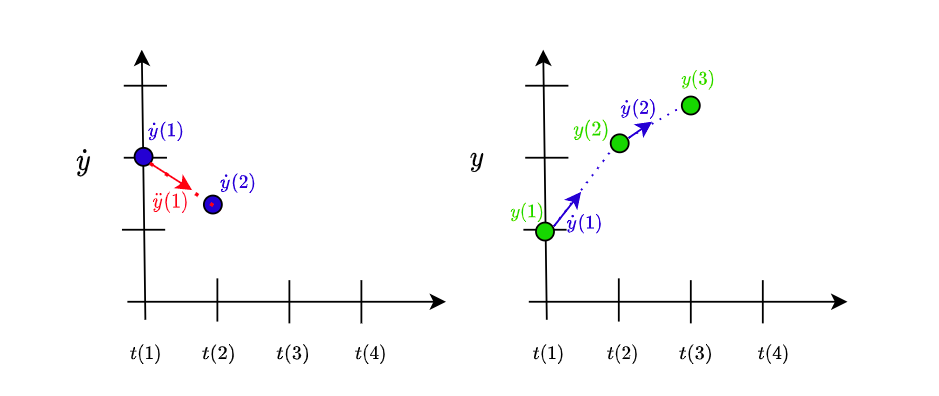

The difficulty with this approach is that $\ddot{y}$ *depends on our last estimate of $\dot{y}$, $\dot{y}(k-1)$ as well as our last estimate of $y$, $y(k-1)$ and our last input $u(k-1)$.* This means that the two integration operations have to occur in the *same* loop. The structure of such a loop can be summarized as follows, where `yd` represents $\dot{y}$ and `ydd` represents $\ddot{y}$:

```
for k in range(1,len(t))
    # compute second derivative of output based on model equation, represented here by "f."
    ydd[k-1] = f(yd[k-1],y[k-1],u[k-1]);
    # now extrapolate once to get our new estimate of the first derivative of y
    yd[k] = yd[k-1] + (t[k]-t[k-1])*ydd[k-1];
    # now extrapolate a second time to get our new estimate of y itself.
    y[k] = y[k-1] + (t[k]-t[k-1])*yd[k-1];
```

Notice that we are are not using the *new* estimate of $\dot{y}$ in the second integration! See the figure above to see why-- we are calculating the slope of each function one timestep behind where we would like to predict *to*.

Also note that for this approach to work, an initial condition for $y$ is needed along with an initial condition for $\dot{y}$ so that the values `y(1)` and `yd(1)` are known, and can be used as the starting point for extrapolation on the first iteration of the loop.

## Simulating Higher-Order Differential Equation Models In State Space Form Using Euler Integration

As we did above for input-output systems, we will need to extrapolate more than one time in each "loop" of our Euler integration code. This is because we will need to compute one derivative for each state variable at each timestep, and update all of the state variables before moving on, **because of the coupling between the list of first-order differential equations** in our model. This is fairly simple, and can be done very easily for systems of *very* high order (for an input-output model, this would be much harder). Code that implements this can be put in a for-loop as follows:

```
for k in range(1,len(t)):
    # compute the derivative of each state based on model equations.
    x1d[k-1] = f(x1[k-1],x2[k-1],...,xn[k-1],u[k-1]);
    x1d[k-1] = f(x1[k-1],x2[k-1],...,xn[k-1],u[k-1]);
    ... #could be many of these... then the last one xn:
    xnd[k-1] = f(x1[k-1],x2[k-1],...,xn[k-1],u[k-1]);
    # now extrapolate once for each state to get our new estimates.
    x1[k] = x1[k-1] + (t[k]-t[k-1])*x1d[k-1];
    x2[k] = x2[k-1] + (t[k]-t[k-1])*x2d[k-1];
    ... #repeat for as many states as you have
    xn[k] = xn[k-1] + (t[k]-t[k-1])*xnd[k-1];
```